# Weather and Corn Yield Regressions

Lauren Kremer

06 March, 2022

## Weather Data Analysis

### Load the PRISM daily maximum temperatures

## Temperature trends

### Summer temperature trends: Winneshiek County

### Winter Temperatures - Winneshiek County

### Multiple regression – Quadratic time trend

### Download NASS corn yield data

## Assignment

### Question 1a: Extract Winneshiek County corn yields, fit a linear time trend, make a plot. Is there a significant time trend?

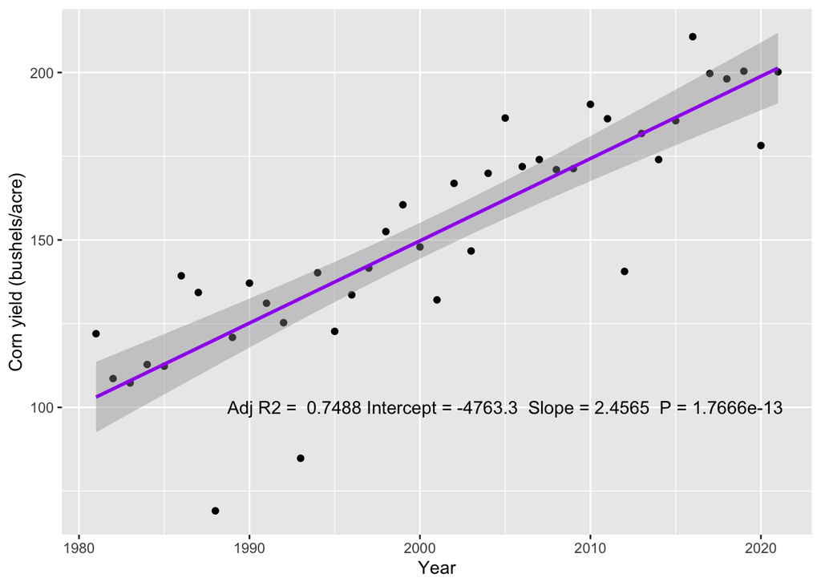

**RESPONSE**  
**Yes, there is a significant increase in corn yield over time for Winneshiek County, IA**

### Question 1b: Fit a quadratic time trend (i.e., year + year^2) and make a plot. Is there evidence for slowing yield growth?

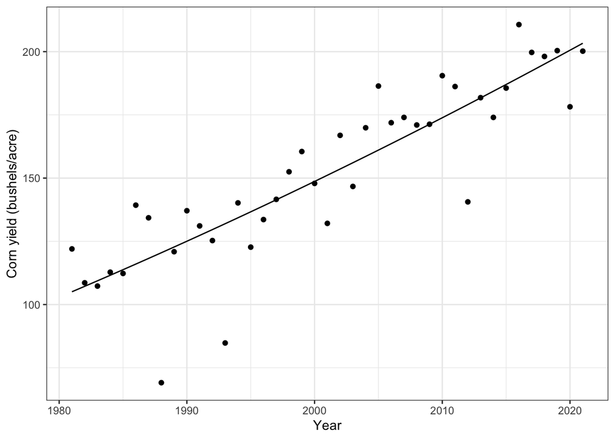

**RESPONSE**  
**No, there does not appear to be a change in yield growth over time for Winneshiek County, IA**

### Question 2 – Time Series: Let’s analyze the relationship between temperature and yields for the Winneshiek County time series. Use data on yield and summer avg Tmax. Is adding year or Tmax^2 to your model helpful? Make a plot and interpret the results.

```
## tibble [38 × 2] (S3: tbl_df/tbl/data.frame)
##  $ year    : num [1:38] 1981 1982 1983 1984 1985 ...
##  $ meantmax: num [1:38] 26.1 25.7 28.7 26.9 25.9 ...
```

```
## tibble [41 × 6] (S3: tbl_df/tbl/data.frame)
##  $ county_ansi: num [1:41] 191 191 191 191 191 191 191 191 191 191 ...
##  $ county_name: chr [1:41] "WINNESHIEK" "WINNESHIEK" "WINNESHIEK" "WINNESHIEK" ...
##  $ yield      : num [1:41] 200 178 200 198 200 ...
##  $ year       : int [1:41] 2021 2020 2019 2018 2017 2016 2015 2014 2013 2012 ...
##  $ yearsq     : num [1:41] 4084441 4080400 4076361 4072324 4068289 ...
##  $ fitted     : Named num [1:41] 203 201 198 195 192 ...
##   ..- attr(*, "names")= chr [1:41] "1" "2" "3" "4" ...
```

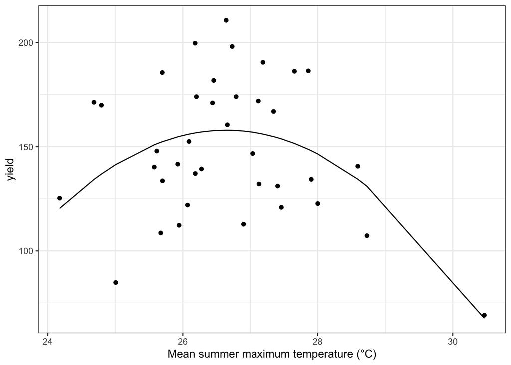

### Question 3 – Cross-Section: Analyze the relationship between temperature and yield across all counties in 2018. Is there a relationship? Interpret the results.

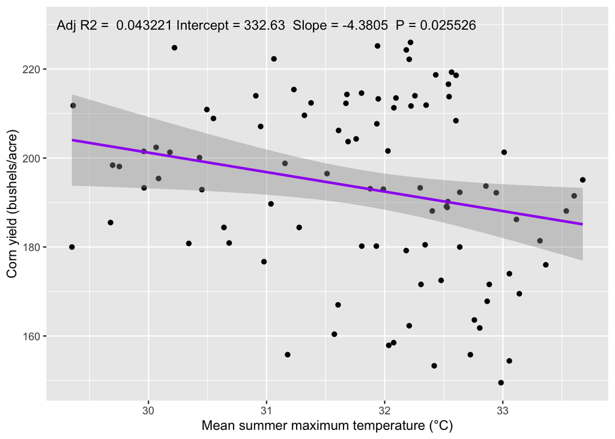

**RESPONSE**  
**There appears to be a significant decrease in corn yield with increasing temperature for all Iowa counties in this dataset (i.e. corn crops are less productive in hot summers)**

### Question 4 – Panel: One way to leverage multiple time series is to group all data into what is called a “panel” regression. Convert the county ID code (“countyfp” or “county_ansi”) into factor using as.factor, then include this variable in a regression using all counties’ yield and summer temperature data. How does the significance of your temperature coefficients (Tmax, Tmax^2) change? Make a plot comparing actual and fitted yields and interpret the results of your model.

```
## tibble [93 × 7] (S3: tbl_df/tbl/data.frame)
##  $ county_ansi: num [1:93] 21 35 41 59 63 119 141 143 147 149 ...
##  $ county_name: chr [1:93] "BUENA VISTA" "CHEROKEE" "CLAY" "DICKINSON" ...
##  $ yield      : num [1:93] 193 213 158 160 156 ...
##  $ year       : num [1:93] 2018 2018 2018 2018 2018 ...
##  $ countyfp   : Factor w/ 99 levels "1","3","5","9",..: 10 17 20 28 30 57 67 68 70 71 ...
##  $ doy        : num [1:93] 152 152 152 152 152 152 152 152 152 152 ...
##  $ tmax       : num [1:93] 31.9 31.9 32.1 31.6 31.2 ...
```

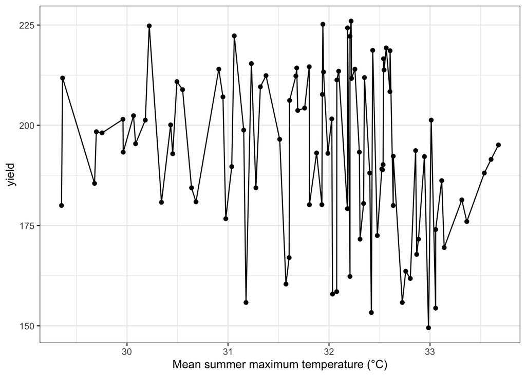

**RESPONSE**  
**The county code is not a variable that influences the relationship between temperature and yield, rather it is an arbitrary factor variable. A linear model that includes this variable could obscure the relationships among other variables.**

### Question 5 – Soybeans: Download NASS data on soybean yields and explore either a time series relationship for a given county, the cross-sectional relationship for a given year, or a panel across all counties and years.

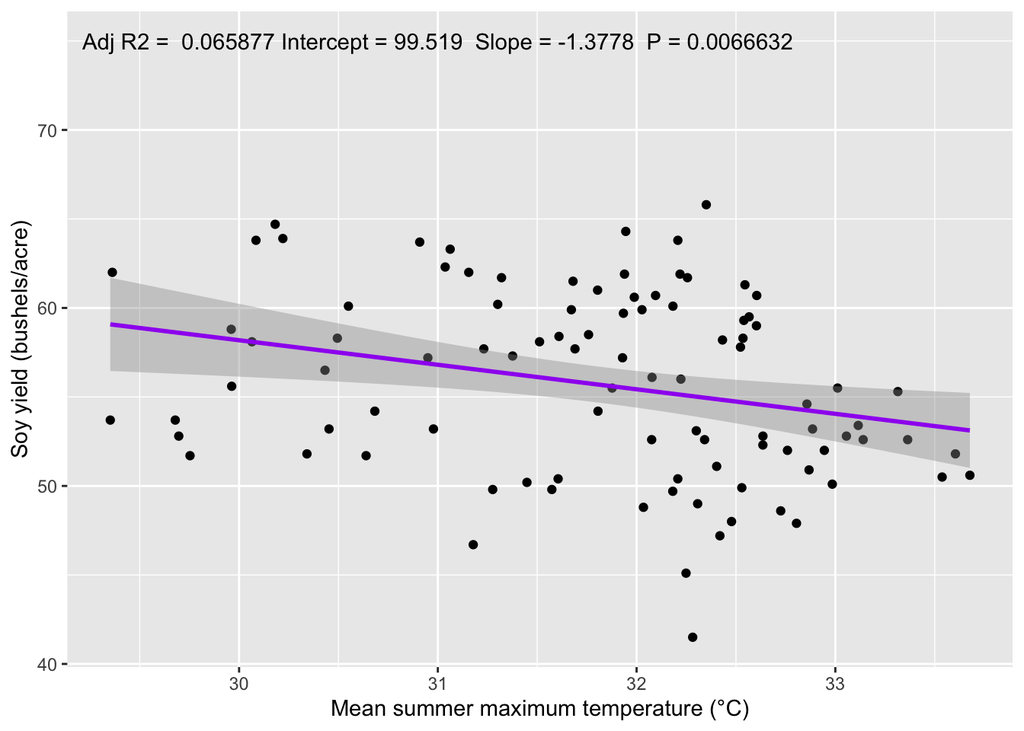

### Bonus: Find a package to make a county map of Iowa displaying some sort of information about yields or weather. Interpret your map.

[interactive chart not shown]

**RESPONSE**  
**There appears to be a transition to cooler temperatures from the south west corner of the state to the east and northern boundaries.**

### Bonus #2: Challenge question - map trends in corn yields by county across Iowa. Interpret your map.

[interactive chart not shown]

**RESPONSE**  
**There appears to be a transition to higher yeilds from the southwest corner to the northern and eastern borders of Iowa. This seems to correlate with the negative correlation between summer max temperatures and corn yield visualized above.**